# **✨ Red Wine Quality Prediction ✨**

# **⚙️ Data Preprocessing ⚙️**

### 1. Computing Skewness of Each Numeircal Attributes.

```python
new_df  = df.copy()
columns = df.columns.tolist()
columns.remove("quality")
```

```python
skew_df = df[columns].skew().to_frame().rename(columns={0:"Skewness"})
skew_df
```

|  | Skewness |
| --- | --- |
| fixed acidity | 0.941041 |
| volatile acidity | 0.729279 |
| citric acid | 0.312726 |
| residual sugar | 4.548153 |
| chlorides | 5.502487 |
| free sulfur dioxide | 1.226579 |
| total sulfur dioxide | 1.540368 |
| density | 0.044778 |
| pH | 0.232032 |
| sulphates | 2.406505 |
| alcohol | 0.859841 |

### 💬 Inference:

- Except **Density**, **pH**, **citric acid** all the other features are having **high skewness.**
- Skewness can lead to several implications like **model performance**, **hypothesis testing** and it returns **biased estimation.**
- So we will use **tranformation techniques** to transform thesse feature to have a **symmetric distribution.**

### 2. Performing Skewness Transformation Analysis using Different Transformation Techniques.

```python
columns = df.columns.tolist()
columns.remove("quality")
skewness_transformation = {}

for col in columns:
    transformed_log = np.log(df[col])                        # Log Transformation
    transformed_boxcox = special.boxcox1p(df[col], 0.15)     # Box-Cox Transformation with lambda=0.15
    transformed_inverse = 1 / df[col]                        # Inverse Transformation
    transformed_yeojohnson, _ = stats.yeojohnson(df[col])    # Yeo-Johnson Transformation
    transformed_cbrt = np.cbrt(df[col])                      # Cube Root Transformation

    # Create a dictionary for the skewness values of each transformation
    transformation_skewness = {
        "Log Transformation": stats.skew(transformed_log),
        "Box-Cox Transformation": stats.skew(transformed_boxcox),
        "Inverse Transformation": stats.skew(transformed_inverse),
        "Yeo Johnson Transformation": stats.skew(transformed_yeojohnson),
        "Cube Root Transformation": stats.skew(transformed_cbrt)}

    # Store the transformation skewness values for the column
    skewness_transformation[col] = transformation_skewness
```

```python
result_df = pd.DataFrame.from_dict(skewness_transformation, orient='index')
result_df = pd.concat([skew_df["Skewness"], result_df], axis=1)
result_df
```

|  | Skewness | Log Transformation | Box-Cox Transformation | Inverse Transformation | Yeo Johnson Transformation | Cube Root Transformation |
| --- | --- | --- | --- | --- | --- | --- |
| fixed acidity | 0.941041 | 0.348419 | 0.488956 | 0.252181 | 0.001881 | 0.543481 |
| volatile acidity | 0.729279 | -0.330430 | 0.385526 | 1.554967 | 0.008302 | 0.009328 |
| citric acid | 0.312726 | NaN | 0.114207 | NaN | 0.016544 | -1.090854 |
| residual sugar | 4.548153 | 1.763289 | 2.475999 | -0.182912 | -0.001713 | 2.490603 |
| chlorides | 5.502487 | 1.885558 | 5.004319 | 4.269093 | -0.061854 | 3.065217 |
| free sulfur dioxide | 1.226579 | -0.219826 | 0.090191 | 3.255936 | -0.009888 | 0.246108 |
| total sulfur dioxide | 1.540368 | -0.078074 | 0.165055 | 1.522798 | -0.003893 | 0.392382 |
| density | 0.044778 | 0.036798 | 0.041363 | -0.028870 | -0.002809 | 0.039441 |
| pH | 0.232032 | 0.039720 | 0.105560 | 0.147883 | -0.005001 | 0.103082 |
| sulphates | 2.406505 | 0.960399 | 1.726855 | -0.069449 | 0.014621 | 1.349370 |
| alcohol | 0.859841 | 0.662627 | 0.704339 | -0.484275 | 0.116613 | 0.725828 |

### 💬 Inference:

- Out of all the transformation the **Yeo Johnson Transformation** has given the **best results** by reducing the skewness.
- **Inverse transformation** performation is also good on some of the features.
- But we will use **Yeo Johnson Transformation** to achieve th **Normal Distribution.**

### 3. Applying Yeo - Johnson Transformation on Independent variables.

```python
for col in columns:
    transformed_col,_ = stats.yeojohnson(df[col])
    df[col] = transformed_col
```

```python
df.sample(5)
```

|  | fixed acidity | volatile acidity | citric acid | residual sugar | chlorides | free sulfur dioxide | total sulfur dioxide | density | pH | sulphates | alcohol | quality |
| --- | --- | --- | --- | --- | --- | --- | --- | --- | --- | --- | --- | --- |
| 589 | 1.083009 | 0.225524 | 0.375740 | 0.454783 | 0.035040 | 1.903885 | 2.723567 | 0.090742 | 0.941016 | 0.215624 | 0.267964 | 7 |
| 1090 | 1.080283 | 0.206950 | 0.404863 | 0.434792 | 0.041241 | 4.278243 | 4.546746 | 0.090742 | 0.933546 | 0.208209 | 0.267974 | 8 |
| 515 | 1.056611 | 0.398169 | 0.375740 | 0.481850 | 0.046981 | 4.015134 | 5.336068 | 0.090743 | 0.967034 | 0.229303 | 0.267949 | 5 |
| 862 | 1.036744 | 0.297055 | 0.266332 | 0.456744 | 0.037420 | 2.231460 | 3.387543 | 0.090742 | 0.960283 | 0.187139 | 0.267963 | 5 |
| 1428 | 1.043126 | 0.392570 | -0.000000 | 0.434792 | 0.038738 | 3.733998 | 4.224166 | 0.090742 | 0.967034 | 0.208209 | 0.267968 | 5 |

### 4. Comparining Distribution of Features Before & After Transformations.

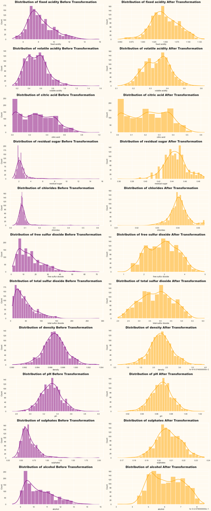

```python
x=1
y=2


plt.figure(figsize=(25,60))
for col in columns:
    plt.subplot(11,2,x)
    sns.histplot(new_df[col],kde=True,color="purple")
    plt.title(f"Distribution of {col} Before Transformation",fontweight="black",size=25,pad=10)
    x+=2

    plt.subplot(11,2,y)
    sns.histplot(df[col],kde=True, color="orange")
    plt.title(f"Distribution of {col} After Transformation",fontweight="black",size=25,pad=10)
    y+=2

    plt.tight_layout()
```

### 💬 Inference:

- We can clearly observe the **changes** their Distrbutions.
- Most of the **features** has achieved **Normal Distribution.**

### 4. Splitting Target Variable into two Groups.

```python
df["quality"].unique()
```

```
array([5, 6, 7, 4, 8, 3], dtype=int64)
```

```python
#Condition of Splitting: If quality > 6.5 => "good" ELSE => "bad"

bin_edges = [0,6.5,10]
group_names = ["Bad","Good"]

df["quality"] = pd.cut(df["quality"], bins=bin_edges, labels=group_names)
df["quality"].unique()
```

```
['Bad', 'Good']
Categories (2, object): ['Bad' < 'Good']
```

### 5. Visualizing the New Distribution of Target Variable.

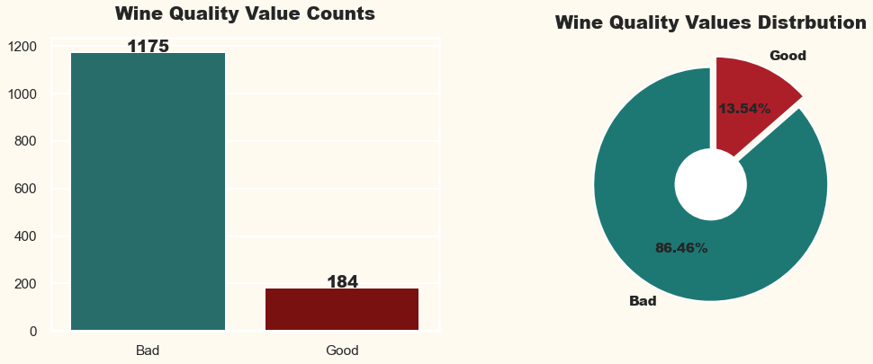

```python
plt.figure(figsize=(17,6))
plt.subplot(1,2,1)
quality_counts = df["quality"].value_counts()
sns.barplot(x=quality_counts.index, y=quality_counts.values,palette=["#1d7874","#8B0000"])
plt.title("Wine Quality Value Counts",fontweight="black",size=20,pad=20)
for i, v in enumerate(quality_counts.values):
    plt.text(i, v, v,ha="center", fontweight='black', fontsize=18)

plt.subplot(1,2,2)
plt.pie(quality_counts, labels=["Bad","Good"], autopct="%.2f%%", textprops={"fontweight":"black","size":15},
        colors = ["#1d7874","#AC1F29"],explode=[0,0.1],startangle=90)
center_circle = plt.Circle((0, 0), 0.3, fc='white')
fig = plt.gcf()
fig.gca().add_artist(center_circle)
plt.title("Wine Quality Values Distrbution" ,fontweight="black",size=20,pad=10)
plt.show()
```

### 💬 Inference:

- We can still observe **class - imbalance**.
- The dataset is having more **Bad Quality Wines** and very **low Good quality wines.**

### 6. Encoding Target Variable.

```python
df["quality"] = df["quality"].replace({"Bad":0,"Good":1})
```

```python
df.sample(5)
```

|  | fixed acidity | volatile acidity | citric acid | residual sugar | chlorides | free sulfur dioxide | total sulfur dioxide | density | pH | sulphates | alcohol | quality |
| --- | --- | --- | --- | --- | --- | --- | --- | --- | --- | --- | --- | --- |
| 931 | 1.034526 | 0.381063 | 0.009935 | 0.438536 | 0.039231 | 2.887073 | 3.827766 | 0.090742 | 0.982720 | 0.209752 | 0.267956 | 0 |
| 288 | 1.060143 | 0.343854 | 0.085068 | 0.452650 | 0.042769 | 3.377706 | 4.099629 | 0.090742 | 0.969874 | 0.221373 | 0.267965 | 1 |
| 126 | 1.051056 | 0.576286 | -0.000000 | 0.425999 | 0.040822 | 1.452799 | 2.644732 | 0.090742 | 0.987153 | 0.194068 | 0.267968 | 0 |
| 568 | 1.077467 | 0.334987 | 0.375740 | 0.454783 | 0.052243 | 1.903885 | 3.157361 | 0.090743 | 0.967034 | 0.218263 | 0.267966 | 0 |
| 1323 | 1.066832 | 0.265718 | 0.313487 | 0.430634 | 0.035357 | 3.434855 | 4.224166 | 0.090742 | 0.954351 | 0.219672 | 0.267968 | 1 |

### 7. Splitting Dataset using StratifiedKFold Method.

```python
df2 = df.drop(columns="quality")
n_splits = 5  # Set the number of folds
stratified_kfold = StratifiedKFold(n_splits=n_splits, shuffle=True, random_state=42)
```

```python
for train_index, test_index in stratified_kfold.split(df2, df["quality"]):
    x_train, x_test = df2.iloc[train_index], df2.iloc[test_index]
    y_train, y_test = df["quality"].iloc[train_index], df["quality"].iloc[test_index]
```

```python
print(x_train.shape,y_train.shape)
print(x_test.shape,y_test.shape)
```

```
(1088, 11) (1088,)
(271, 11) (271,)
```

### 💬 Inference:

- The data is **splitted** in **two sets** one for Model Training and another for Model performance Testing.
- We will use **Train Dataset** to train the model and **Test Dataset** to evaluate the performance of the model.

### 8. Computing Frequeny of Unique Values in Y_Train & Y_Test.

```python
unique_df = y_train.value_counts().to_frame().rename(columns={"quality":"Y_train Target frequency"})
unique_df["Y_test target Freequency"] = y_test.value_counts()
unique_df
```

|  | Y_train Target frequency | Y_test target Freequency |
| --- | --- | --- |
| 0 | 940 | 235 |
| 1 | 148 | 36 |

### 💬 Inference:

- Both the categories in **target variable** is splitter in such a way that **model learns and create pattern** for both the categories easily.